# linear regression-gradient descent exercise

```python
import numpy as np
import pandas as pd
import matplotlib.pyplot as plt
from sklearn import linear_model
from sklearn.model_selection import train_test_split
from sklearn.metrics import accuracy_score
from mpl_toolkits.mplot3d import Axes3D
%matplotlib inline
```

### 1. Load pre-prepared data

```python
df = pd.read_csv("ex1data2.csv")
```

```python
df.head()
```

|  | 2104 | 3 | 399900 |
| --- | --- | --- | --- |
| 0 | 1600 | 3 | 329900 |
| 1 | 2400 | 3 | 369000 |
| 2 | 1416 | 2 | 232000 |
| 3 | 3000 | 4 | 539900 |
| 4 | 1985 | 4 | 299900 |

```python
lbls = ['size', 'rooms', 'price']
```

```python
df = pd.read_csv("ex1data2.csv", header=None, names=lbls)
```

```python
df.head()
```

|  | size | rooms | price |
| --- | --- | --- | --- |
| 0 | 2104 | 3 | 399900 |
| 1 | 1600 | 3 | 329900 |
| 2 | 2400 | 3 | 369000 |
| 3 | 1416 | 2 | 232000 |
| 4 | 3000 | 4 | 539900 |

### 2. Exploring the data

```python
df.describe()
```

|  | size | rooms | price |
| --- | --- | --- | --- |
| count | 47.000000 | 47.000000 | 47.000000 |
| mean | 2000.680851 | 3.170213 | 340412.659574 |
| std | 794.702354 | 0.760982 | 125039.899586 |
| min | 852.000000 | 1.000000 | 169900.000000 |
| 25% | 1432.000000 | 3.000000 | 249900.000000 |
| 50% | 1888.000000 | 3.000000 | 299900.000000 |
| 75% | 2269.000000 | 4.000000 | 384450.000000 |
| max | 4478.000000 | 5.000000 | 699900.000000 |

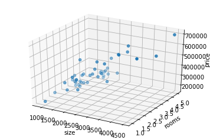

```python
plot = plt.figure().gca(projection='3d')
plot.scatter(df['size'], df['rooms'], df['price'])
plot.set_xlabel('size')
plot.set_ylabel('rooms')
plot.set_zlabel('price')
plt.show()
```

### 2.5 Feature Normalization

The scale of the features (size, rooms) is not *very nice* and will cause room size to have too much weight during training. Feature normalization must be done.

a feature matrix, X, can be normalized by: $$ \frac{X - \mu_X}{\sigma_X} $$

```python
'''
In: Dataframe object, Out: Normalized version of dataframe object
'''
def normalize(df):
    if not(isinstance(df, pd.DataFrame)):
        raise Exception("Dataframe object required")
    else:
        return (df - df.mean()) / df.std()
```

```python
df_norm = normalize(df) #normalize the dataframe
```

### 3. Split the dataframe into a training subset and testing subsets to get a more **general** regression model

```python
X_train, X_test, y_train, y_test = train_test_split(df_norm[['size','rooms']], df_norm['price'], test_size=.4, random_state=0)
```

### 4. Use sklearn to perform initial regression just to confirm our data can work and give us a good idea of how to write our own linear regression model

```python
clf = linear_model.LinearRegression()
clf.fit(X_train, y_train)
```

```
LinearRegression(copy_X=True, fit_intercept=True, n_jobs=1, normalize=False)
```

```python
pred = clf.predict(X_test)
```

```python
#quick and dirty cost function
def j(m, loss):
    return (1/(2*m))*np.sum(np.power(loss,2))
```

The cost function under the sklearn linear regression model:

```python
j(19, (pred - y_test))
```

```
0.22350652886220512
```

```python
print(y_test)
```

```
28    1.076355
33    1.915287
30    0.075875
4     1.595389
18    1.276275
11    0.052682
42   -0.211234
31   -1.363666
22   -0.779852
10   -0.803053
27    1.028370
32   -0.204036
29   -0.323998
43   -0.331196
2     0.228626
45   -0.323998
26    0.992382
15    0.875619
25   -0.723870
Name: price, dtype: float64
```

```
(47,)
```

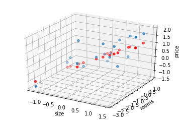

```python
plot = plt.figure().gca(projection='3d')
print(df_norm['rooms'].shape)
plot.scatter(X_test['size'], X_test['rooms'], y_test.values)
plot.scatter(X_test['size'],X_test['rooms'],pred, color='R')
plot.set_xlabel('size')
plot.set_ylabel('rooms')
plot.set_zlabel('price')
plt.show()
```

To perform regression above, we simply used the scikit learn library:

[output not shown]

### Linear regression using BFGS

Here we are going to implement linear regression that can be used the same way as the sklearn linear regression. BFGS will be used to minimize the cost function

h(x) - Hypothesis $$ h_\theta(X^{(i)}) - y^{(i)}) = \theta^T * X = X*\theta\ ; \theta\in R^{(n)}$$

Cost function: $$j(\theta) = \frac{1}{2m}\sum\limits_{i=1}^m(h_\theta(x^{(i)})-y^{(i)})^2$$ $$ = \frac{1}{2m}*\sum(loss^2) $$

I will be using another dataset from the same machine learning class to debugging simple:

```python
test_data = pd.read_csv("ex1data1.csv", header=None, names=['population','profit'])
```

```python
from scipy import optimize
from scipy.optimize import minimize
```

```python
class LinearRegression():
    def __init__(self):
        self.ALPHA= .01
        self.EPSILON = 0
        self.ITER_LIMIT = 1500
        self.EPSILON = .00000001

    def add_bias_col(self, X):
        return np.column_stack((np.ones(X.shape[0]), X))

    def j(self, Theta, *args):
        X = args[0]
        y = args[1]
        [m, n] = X.shape
        loss = np.dot(X,Theta.reshape(n,1)) - y
        return (1/(2*m))*(sum(np.power(loss,2)))

    def pred(self, X):
        if isinstance(X,pd.DataFrame):
            X = X.values
        X = self.add_bias_col(X)
        return np.dot(X,self.Theta.reshape(X.shape[1],1))

    def check_error(self, h, y):
        m = len(h)
        loss = h.reshape(m,1)-y.reshape(m,1)
        return (1/(2*m))*(sum(np.power(loss,2)))

    def fit(self, X, y, debug):
        #if dataframe, convert to numpy array

        if isinstance(X,pd.DataFrame):
            X = X.values
        if isinstance(y,pd.Series):
            y = y.values.reshape(len(y.values),1)

        X = self.add_bias_col(X)
        self.Theta = np.zeros((X.shape[1], 1)) #initialize Theta

        #minimize with BFGS using scipy optimize
        optim = minimize(self.j, self.Theta.reshape(X.shape[1],1), method='BFGS', args=(X, y), options={'disp': True if debug else False})
        self.Theta = optim['x']
```

Note: I got lazy on this part and decided not to split the data

```python
# alpha= .01
# lmbda = 0
# limit = 1500
# epsilon = .00000008
clf = LinearRegression()
clf.fit(test_data['population'],test_data['profit'], debug=True) #added a debug mode to toggle wether to display results or not
```

```
Optimization terminated successfully.
         Current function value: 4.476971
         Iterations: 8
         Function evaluations: 36
         Gradient evaluations: 9
[-3.89578732  1.1930344 ]
```

```python
clf.fit(X_train[['size', 'rooms']], y_train, debug=True)
```

```
Optimization terminated successfully.
         Current function value: 0.074944
         Iterations: 6
         Function evaluations: 35
         Gradient evaluations: 7
[-0.09158071  0.88700545 -0.0700774 ]
```

```python
pred = clf.pred(X_test)
clf.check_error(pred, y_test.values)
```

```
array([ 0.22350685])
```

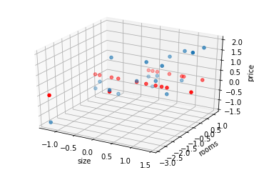

```python
plot = plt.figure().gca(projection='3d')
plot.scatter(X_test['size'], X_test['rooms'], y_test.values)
plot.scatter(X_test['size'],X_test['rooms'],pred, color='R')
plot.set_xlabel('size')
plot.set_ylabel('rooms')
plot.set_zlabel('price')
plt.show()
```

### Gradient Descent

Instead of using a built in library for minimization, we will perform gradient descent to find the theta to minimize the cost function.

Gradient Descent

Gradient descent is simply, the current theta - learning rate*gradient of the cost function w.r.t Theta:  
Here the gradient (partial derivative of the cost function wrt theta) is pre-calculated:

$$\theta_j\ :=\theta_j - \alpha*\delta$$ $$\theta_j\ :=\theta_j - \alpha*\frac{1}{m}*\sum\limits_{i=1}^m((h_\theta(X^{(i)}) - y^{(i)}) * X^{(i)})$$ $$\delta = \frac{1}{m}*\sum(loss * X^{(i)}) $$ $$loss\in R^{(m)}\ X\in R^{m \times n+1}$$

```python
class LinearRegression_GD():
    def __init__(self):
        self.ALPHA= .01
        self.EPSILON = 0
        self.ITER_LIMIT = 1500
        self.EPSILON = .00000001

    def add_bias_col(self, X):
        return np.column_stack((np.ones(X.shape[0]), X))

    def calc_loss(self,X, y, Theta):
        n = X.shape[1]
        return np.dot(X,Theta.reshape(n,1)) - y

    def j(self, Theta, *args):
        X = args[0][0]
        y = args[0][1]
        [m, n] = X.shape
        loss = self.calc_loss(X,y,Theta.reshape(n,1))
        return (1/(2*m))*(sum(np.power(loss,2)))

    def pred(self, X):
        if isinstance(X,pd.DataFrame):
            X = X.values
        X = self.add_bias_col(X)
        return np.dot(X,self.Theta.reshape(X.shape[1],1))

    def check_error(self, h, y):
        m = len(h)
        loss = h.reshape(m,1)-y.reshape(m,1)
        return (1/(2*m))*(sum(np.power(loss,2)))

    def calc_grad(self,Theta,X,y):
        [m,n] = X.shape
        loss = self.calc_loss(X,y,Theta.reshape(n,1))
        return (1/m)*np.dot(X.transpose(),loss)

    def gradient_descent(self, fun, x, *args, debug):
        breakpoint = -1
        old_cost = None
        history = []
        X = args[0][0]
        y = args[0][1]

        for i in range(1,self.ITER_LIMIT):
            cost = fun(x, (X,y))
            gradient = self.calc_grad(x,X,y)
            #break if error is tolerable
            if(i >1 and abs(cost - old_cost) <= self.EPSILON):
                old_cost = cost
                breakpoint = i
                break

            #update
            x = x - self.ALPHA*gradient
            old_cost = cost
            history.append(old_cost)

        if debug:
            print(x)
            print('final cost: ', old_cost, 'broke at:', breakpoint)
            plt.xlabel('iterations')
            plt.ylabel('cost')
            plt.plot(history)

        return {'x': x, 'cost': old_cost, 'history':history}

    def fit(self, X, y, debug):
        #if dataframe, convert to numpy array

        if isinstance(X,pd.DataFrame):
            X = X.values
        if isinstance(y,pd.Series):
            y = y.values.reshape(len(y.values),1)

        X = self.add_bias_col(X)
        self.Theta = np.zeros((X.shape[1], 1)) #initialize Theta

        #minimize with BFGS using scipy optimize
        # optim = minimize(self.j, self.Theta.reshape(X.shape[1],1), method='BFGS', args=(X, y), options={'disp': True if debug else False})
        # self.Theta = optim['x']

        #minimize using gradient descent
        optim = self.gradient_descent(self.j, self.Theta, (X,y), debug=debug)
        self.Theta = optim['x']
```

```
[[-3.62981201]
 [ 1.16631419]]
final cost:  [ 4.48343473] broke at: -1
```

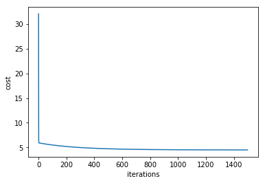

```python
# alpha= .01
# lmbda = 0
# limit = 1500
# epsilon = .00000008
clf = LinearRegression_GD()
clf.fit(test_data['population'],test_data['profit'], debug=True)
```

```
[[-0.09162732]
 [ 0.88550001]
 [-0.06819642]]
final cost:  [ 0.0749454] broke at: 1331
```

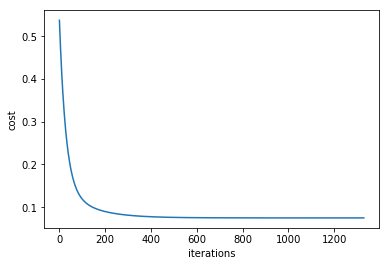

```python
clf.fit(X_train[['size', 'rooms']], y_train, debug=True)
```

The iterations vs cost plot is used to check if the cost is being reduced per iteration

```python
pred = clf.pred(X_test)
clf.check_error(pred, y_test.values)
```

```
array([ 0.22347393])
```

```
(47,)
```

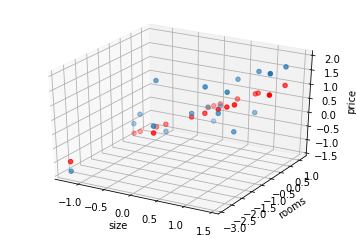

```python
plot = plt.figure().gca(projection='3d')
print(df_norm['rooms'].shape)
plot.scatter(X_test['size'], X_test['rooms'], y_test.values)
plot.scatter(X_test['size'],X_test['rooms'],pred, color='R')
plot.set_xlabel('size')
plot.set_ylabel('rooms')
plot.set_zlabel('price')
plt.show()
```